# 데이터마이닝 과제1

## duration & campaign & pdays & previous

이전 접촉과 관련된 자료

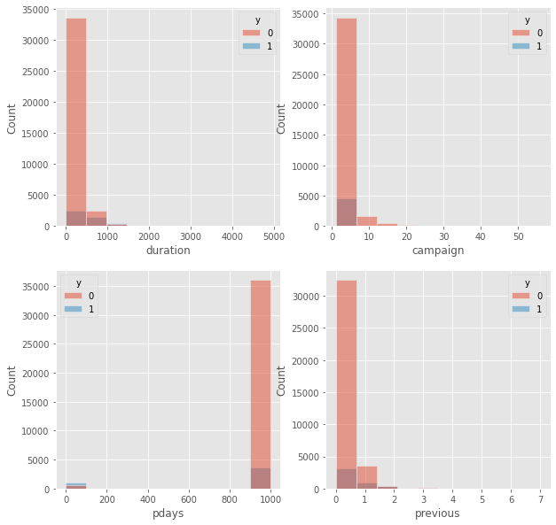

```python
plt.figure(figsize=(10,10))
plt.subplot(2,2,1)
sns.histplot(x='duration',hue='y',bins=10,data=train)
plt.subplot(2,2,2)
sns.histplot(x='campaign',hue='y',bins=10,data=train)
plt.subplot(2,2,3)
sns.histplot(x='pdays',hue='y',bins=10,data=train)
plt.subplot(2,2,4)
sns.histplot(x='previous',hue='y',bins=10,data=train)
```

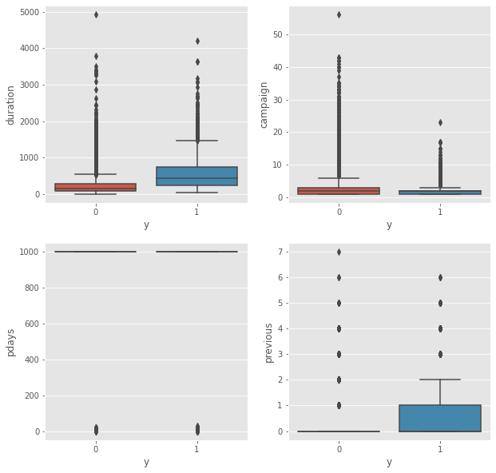

```python
plt.figure(figsize=(10,10))
plt.subplot(2,2,1)
sns.boxplot(data=train,y=train['duration'],x=train['y'])
plt.subplot(2,2,2)
sns.boxplot(data=train,y=train['campaign'],x=train['y'])
plt.subplot(2,2,3)
sns.boxplot(data=train,y=train['pdays'],x=train['y'])
plt.subplot(2,2,4)
sns.boxplot(data=train,y=train['previous'],x=train['y'])
```

- duaration은 커질수록 비율이 높아지는 경향이 있고
- campaign은 낮을 수록 유의하다
- pdays는 999는 접촉하지 않았음을 의미한다. 그래서 범주형 변수로 변환해야한다.
- previous는 유의한지 판단이 어렵다.

```python
print("duration : ",kstest(train['duration'], train['y']))
print("campaign : ",kstest(train['campaign'], train['y']))
print("pdays : ",kstest(train['pdays'], train['y']))
print("previous : ",kstest(train['previous'], train['y']))
```

```
duration :  KstestResult(statistic=0.9998300475866757, pvalue=0.0)
campaign :  KstestResult(statistic=0.8873458288821987, pvalue=0.0)
pdays :  KstestResult(statistic=0.9990045644362435, pvalue=0.0)
previous :  KstestResult(statistic=0.0258327668252889, pvalue=2.263920670210774e-12)
```

기각하며, 유의하다고 할 수 있다.

변수들을 모두 사용한다.

## social and economic context attributes

emp.var.rate, cons.price.idx, cons.conf.idx, euribor3m, nr.employed 변수들을 분석

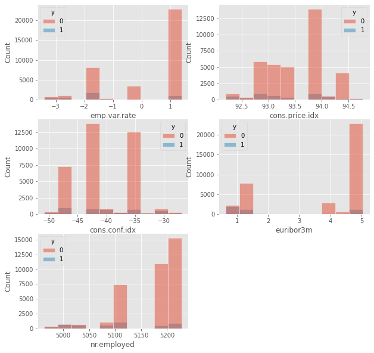

```python
plt.figure(figsize=(10,10))
plt.subplot(3,2,1)
sns.histplot(x='emp.var.rate',hue='y',bins=10,data=train)
plt.subplot(3,2,2)
sns.histplot(x='cons.price.idx',hue='y',bins=10,data=train)
plt.subplot(3,2,3)
sns.histplot(x='cons.conf.idx',hue='y',bins=10,data=train)
plt.subplot(3,2,4)
sns.histplot(x='euribor3m',hue='y',bins=10,data=train)
plt.subplot(3,2,5)
sns.histplot(x='nr.employed',hue='y',bins=10,data=train)
```

데이터가 연속되지 않는 경우가 많다.

박스플롯 사용은 안된다.

```python
print("emp.var.rate : ",kstest(train['emp.var.rate'], train['y']))
print("cons.price.idx : ",kstest(train['cons.price.idx'], train['y']))
print("cons.conf.idx : ",kstest(train['cons.conf.idx'], train['y']))
print("euribor3m : ",kstest(train['euribor3m'], train['y']))
print("nr.employed : ",kstest(train['nr.employed'], train['y']))
```

```
emp.var.rate :  KstestResult(statistic=0.5826211517917841, pvalue=0.0)
cons.price.idx :  KstestResult(statistic=1.0, pvalue=0.0)
cons.conf.idx :  KstestResult(statistic=1.0, pvalue=0.0)
euribor3m :  KstestResult(statistic=0.9051179955326795, pvalue=0.0)
nr.employed :  KstestResult(statistic=1.0, pvalue=0.0)
```

모두 유의하다는 결론이 나온다.

# 변수 가공

위에서 찾은 변수와 target의 관계를 통해 변환을 한다.

```python
train_change = train.copy()
```

```python
# job grouping

train_change['job']=train_change['job'].replace(['blue-collar','services','entrepreneur','housemaid','self-employed','technician',
                           'unknown','management','admin.','unemployed'],'job1')
train_change['job'].unique()
```

```
array(['job1', 'retired', 'student'], dtype=object)
```

```python
# marital grouping

train_change['marital']=train_change['marital'].replace(['married','divorced'],'marital1')
train_change['marital']=train_change['marital'].replace(['single','unknown'],'marital2')
train_change['marital'].unique()
```

```
array(['marital1', 'marital2'], dtype=object)
```

```python
# education grouping

train_change['education']=train_change['education'].replace(['basic.9y','basic.6y','basic.4y','high.school'],'education1')
train_change['education']=train_change['education'].replace(['university.degree','unknown'],'university.degree')
train_change['education'].unique()
```

```
array(['education1', 'professional.course', 'university.degree',
       'illiterate'], dtype=object)
```

```python
# default grouping

train_change['default']=train_change['default'].replace(['unknown'],'yes')
train_change['default'].unique()
```

```
array(['no', 'yes'], dtype=object)
```

```python
# housing & loan 제거

train_change.drop(['housing','loan'],axis=1,inplace=True)
```

```python
# month grouping
# may / jul,nov,jun, aug / apr / oct,sep / dec,mar/ 로 구분할 수 있다.

train_change['month']=train_change['month'].replace(['jul','nov','jun','aug'],'month1')
train_change['month']=train_change['month'].replace(['oct','sep'],'month2')
train_change['month']=train_change['month'].replace(['dec','mar'],'month3')
train_change['month'].unique()
```

```
array(['may', 'month1', 'month2', 'month3', 'apr'], dtype=object)
```

```python
# day_of_week grouping
#mon,fri / tue,wed,thu 으로 구분이된다.

train_change['day_of_week']=train_change['day_of_week'].replace(['mon','fri'],'day1')
train_change['day_of_week']=train_change['day_of_week'].replace(['tue','wed','thu'],'day2')
train_change['day_of_week'].unique()
```

```
array(['day1', 'day2'], dtype=object)
```

```python
# age 제거
train_change.drop('age',axis=1,inplace=True)
```

```python
# pdays 범주형 변환
# 만났으면 1 , 만나지 않았으면 0으로 분류.

train_change['pdays']=train_change['pdays'].where(train_change['pdays'] !=999, 1)
train_change['pdays']=train_change['pdays'].where(train_change['pdays'] ==999, 0)
```

```python
train_change
```

|  | job | marital | education | default | contact | month | day_of_week | duration | campaign | pdays | previous | poutcome | emp.var.rate | cons.price.idx | cons.conf.idx | euribor3m | nr.employed | y |
| --- | --- | --- | --- | --- | --- | --- | --- | --- | --- | --- | --- | --- | --- | --- | --- | --- | --- | --- |
| 0 | job1 | marital1 | education1 | no | telephone | may | day1 | 261 | 1 | 0 | 0 | nonexistent | 1.1 | 93.994 | -36.4 | 4.857 | 5191.0 | 0 |
| 1 | job1 | marital1 | education1 | yes | telephone | may | day1 | 149 | 1 | 0 | 0 | nonexistent | 1.1 | 93.994 | -36.4 | 4.857 | 5191.0 | 0 |
| 2 | job1 | marital1 | education1 | no | telephone | may | day1 | 226 | 1 | 0 | 0 | nonexistent | 1.1 | 93.994 | -36.4 | 4.857 | 5191.0 | 0 |
| 3 | job1 | marital1 | education1 | no | telephone | may | day1 | 151 | 1 | 0 | 0 | nonexistent | 1.1 | 93.994 | -36.4 | 4.857 | 5191.0 | 0 |
| 4 | job1 | marital1 | education1 | no | telephone | may | day1 | 307 | 1 | 0 | 0 | nonexistent | 1.1 | 93.994 | -36.4 | 4.857 | 5191.0 | 0 |
| ... | ... | ... | ... | ... | ... | ... | ... | ... | ... | ... | ... | ... | ... | ... | ... | ... | ... | ... |
| 41183 | retired | marital1 | professional.course | no | cellular | month1 | day1 | 334 | 1 | 0 | 0 | nonexistent | -1.1 | 94.767 | -50.8 | 1.028 | 4963.6 | 1 |
| 41184 | job1 | marital1 | professional.course | no | cellular | month1 | day1 | 383 | 1 | 0 | 0 | nonexistent | -1.1 | 94.767 | -50.8 | 1.028 | 4963.6 | 0 |
| 41185 | retired | marital1 | university.degree | no | cellular | month1 | day1 | 189 | 2 | 0 | 0 | nonexistent | -1.1 | 94.767 | -50.8 | 1.028 | 4963.6 | 0 |
| 41186 | job1 | marital1 | professional.course | no | cellular | month1 | day1 | 442 | 1 | 0 | 0 | nonexistent | -1.1 | 94.767 | -50.8 | 1.028 | 4963.6 | 1 |
| 41187 | retired | marital1 | professional.course | no | cellular | month1 | day1 | 239 | 3 | 0 | 1 | failure | -1.1 | 94.767 | -50.8 | 1.028 | 4963.6 | 0 |

41188 rows × 18 columns

```python
train_change.to_csv('./bankfull_eda.csv',index=False)
```

# 결론